# used_car_regression

## 勾配ブースティング回帰モデルによる中古車価格の推定

### 100,000 UK Used Car Data set (100,000 scraped used car listings, cleaned and split into car make)

### https://www.kaggle.com/adityadesai13/used-car-dataset-ford-and-mercedes

```python
###　scikit-lear版の代わりにFrovedis 勾配ブースティング回帰をインポートしています
```

```python
import pandas as pd
import numpy as np
from datetime import datetime
import os
import matplotlib.pyplot as plt
from mpl_toolkits.mplot3d import axes3d
from sklearn.metrics import mean_squared_error
from sklearn.model_selection import train_test_split
from frovedis.mllib.ensemble import GradientBoostingRegressor
#from sklearn.ensemble import GradientBoostingRegressor
from frovedis.exrpc.server import FrovedisServer
```

### １１のブランドに分けられた中古車データをDataFrameにロードします

```python
vw = pd.read_table('../../data/datasets/used_car/vw.csv', sep=',', engine='python').dropna(how='any')
audi = pd.read_table('../../data/datasets/used_car/audi.csv', sep=',', engine='python').dropna(how='any')
bmw = pd.read_table('../../data/datasets/used_car/bmw.csv', sep=',', engine='python').dropna(how='any')
cclass = pd.read_table('../../data/datasets/used_car/cclass.csv', sep=',', engine='python').dropna(how='any')
focus = pd.read_table('../../data/datasets/used_car/focus.csv', sep=',', engine='python').dropna(how='any')
ford = pd.read_table('../../data/datasets/used_car/ford.csv', sep=',', engine='python').dropna(how='any')
hyundi= pd.read_table('../../data/datasets/used_car/hyundi.csv', sep=',', engine='python').dropna(how='any')
merc = pd.read_table('../../data/datasets/used_car/merc.csv', sep=',', engine='python').dropna(how='any')
skoda = pd.read_table('../../data/datasets/used_car/skoda.csv', sep=',', engine='python').dropna(how='any')
toyota = pd.read_table('../../data/datasets/used_car/toyota.csv', sep=',', engine='python').dropna(how='any')
vauxhall = pd.read_table('../../data/datasets/used_car/vauxhall.csv', sep=',', engine='python').dropna(how='any')
```

### テーブルを確認します

```python
audi.head()
```

|  | model | year | price | transmission | mileage | fuelType | tax | mpg | engineSize |
| --- | --- | --- | --- | --- | --- | --- | --- | --- | --- |
| 0 | A1 | 2017 | 12500 | Manual | 15735 | Petrol | 150 | 55.4 | 1.4 |
| 1 | A6 | 2016 | 16500 | Automatic | 36203 | Diesel | 20 | 64.2 | 2.0 |
| 2 | A1 | 2016 | 11000 | Manual | 29946 | Petrol | 30 | 55.4 | 1.4 |
| 3 | A4 | 2017 | 16800 | Automatic | 25952 | Diesel | 145 | 67.3 | 2.0 |
| 4 | A3 | 2019 | 17300 | Manual | 1998 | Petrol | 145 | 49.6 | 1.0 |

### 排気量データにおいて有効でないレコードが確認されます（排気量=0）

```python
audi.sort_values(by='engineSize')
```

|  | model | year | price | transmission | mileage | fuelType | tax | mpg | engineSize |
| --- | --- | --- | --- | --- | --- | --- | --- | --- | --- |
| 7688 | S4 | 2019 | 39850 | Automatic | 4129 | Diesel | 145 | 40.4 | 0.0 |
| 7647 | Q3 | 2020 | 31990 | Automatic | 1500 | Petrol | 145 | 40.4 | 0.0 |
| 7649 | Q2 | 2020 | 24888 | Automatic | 1500 | Petrol | 145 | 42.2 | 0.0 |
| 7659 | Q3 | 2020 | 32444 | Automatic | 1500 | Petrol | 145 | 31.4 | 0.0 |
| 7662 | Q2 | 2020 | 24990 | Manual | 1500 | Petrol | 145 | 43.5 | 0.0 |
| ... | ... | ... | ... | ... | ... | ... | ... | ... | ... |
| 4391 | R8 | 2018 | 93950 | Semi-Auto | 3800 | Petrol | 145 | 23.0 | 5.2 |
| 4783 | R8 | 2020 | 145000 | Semi-Auto | 2000 | Petrol | 145 | 21.1 | 5.2 |
| 7475 | R8 | 2014 | 59990 | Automatic | 31930 | Petrol | 580 | 21.9 | 5.2 |
| 4742 | R8 | 2019 | 117990 | Automatic | 11936 | Petrol | 145 | 21.4 | 5.2 |
| 10455 | A8 | 2015 | 32000 | Automatic | 30306 | Petrol | 570 | 25.0 | 6.3 |

10668 rows × 9 columns

### 排気量と年式についてフィルタリング実施後、全ブランドについてのDataFrameを一つに統合します。この際、各ブランドのテーブル間で非共通な列が取り除かれます

```python
vw = vw[vw["engineSize"] > 0]
audi = audi[audi["engineSize"] > 0]
bmw = bmw[bmw["engineSize"] > 0]
cclass = cclass[cclass["engineSize"] > 0]
focus = focus[focus["engineSize"] > 0]
ford = ford[ford["engineSize"] > 0]
hyundi = hyundi[hyundi["engineSize"] > 0]
merc = merc[merc["engineSize"] > 0]
skoda = skoda[skoda["engineSize"] > 0]
toyota = toyota[toyota["engineSize"] > 0]
vauxhall = vauxhall[vauxhall["engineSize"] > 0]
vw = vw[(vw["year"] < 2022) & (vw["year"] > 1990)]
audi = audi[(audi["year"] < 2022) & (audi["year"] > 1990)]
bmw = bmw[(bmw["year"]  < 2022) & (bmw["year"] > 1990)]
cclass = cclass[(cclass["year"] < 2022) & (cclass["year"] > 1990)]
focus = focus[(focus["year"] < 2022) & (focus["year"] > 1990)]
ford = ford[(ford["year"] < 2022) & (ford["year"] > 1990)]
hyundi = hyundi[(hyundi["year"] < 2022) & (hyundi["year"] > 1990)]
merc = merc[(merc["year"] < 2022) & (merc["year"] > 1990)]
skoda = skoda[(skoda["year"] < 2022) & (skoda["year"] > 1990)]
toyota = toyota[(toyota["year"] < 2022) & (toyota["year"] > 1990)]
vauxhall = vauxhall[(vauxhall["year"] < 2022) & (vauxhall["year"] > 1990)]
all_brand = pd.concat([vw, audi, bmw, cclass, focus, ford, hyundi, merc, skoda, toyota, vauxhall],join='inner')
```

### 税金と燃費の列が取り除かれていることが確認できます

```python
all_brand.head()
```

|  | model | year | price | transmission | mileage | fuelType | engineSize |
| --- | --- | --- | --- | --- | --- | --- | --- |
| 0 | T-Roc | 2019 | 25000 | Automatic | 13904 | Diesel | 2.0 |
| 1 | T-Roc | 2019 | 26883 | Automatic | 4562 | Diesel | 2.0 |
| 2 | T-Roc | 2019 | 20000 | Manual | 7414 | Diesel | 2.0 |
| 3 | T-Roc | 2019 | 33492 | Automatic | 4825 | Petrol | 2.0 |
| 4 | T-Roc | 2019 | 22900 | Semi-Auto | 6500 | Petrol | 1.5 |

```python
all_brand.describe()
```

|  | year | price | mileage | engineSize |
| --- | --- | --- | --- | --- |
| count | 108252.000000 | 108252.000000 | 108252.000000 | 108252.000000 |
| mean | 2017.098382 | 16890.472740 | 23030.811948 | 1.666039 |
| std | 2.116347 | 9757.417443 | 21184.953118 | 0.551202 |
| min | 1991.000000 | 450.000000 | 1.000000 | 0.600000 |
| 25% | 2016.000000 | 10230.750000 | 7491.000000 | 1.200000 |
| 50% | 2017.000000 | 14698.000000 | 17257.000000 | 1.600000 |
| 75% | 2019.000000 | 20945.000000 | 32245.000000 | 2.000000 |
| max | 2020.000000 | 159999.000000 | 323000.000000 | 6.600000 |

### 学習を実施する前にデータセットの特性を可視化し確認します

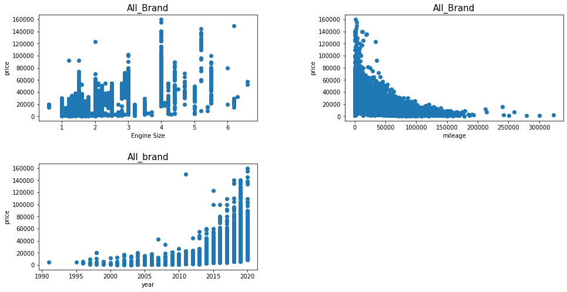

```python
fig = plt.figure(figsize=(16,8))
plt.subplots_adjust(wspace=0.4, hspace=0.4)
ax1 = fig.add_subplot(2,2,1)
ax1.scatter(all_brand['engineSize'], all_brand['price'])
ax1.set_title('All_Brand', size=15)
ax1.set_xlabel('Engine Size')
ax1.set_ylabel('price')
ax2 = fig.add_subplot(2,2,2)
ax2.scatter(all_brand['mileage'], all_brand['price'])
ax2.set_title('All_Brand', size=15)
ax2.set_xlabel('mileage')
ax2.set_ylabel('price')
ax3 = fig.add_subplot(2,2,3)
ax3.scatter(all_brand['year'], all_brand['price'])
ax3.set_title('All_brand', size=15)
ax3.set_xlabel('year')
ax3.set_ylabel('price')
plt.show()
```

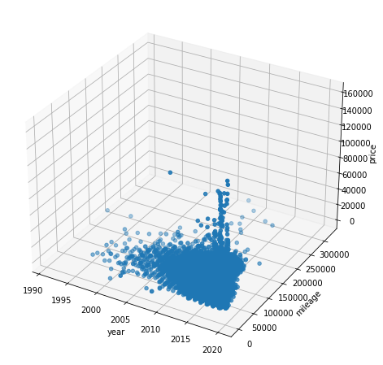

```python
fig = plt.figure(figsize=(16,8))
plt.subplots_adjust(wspace=0.4, hspace=0.4)
ax4 = fig.add_subplot(1,1,1, projection='3d')
ax4.set_xlabel("year")
ax4.set_ylabel("mileage")
ax4.set_zlabel("price")
ax4.scatter(all_brand['year'], all_brand['mileage'], all_brand['price'])
plt.show()
```

### DataFrameから入力データxと出力データyを取り出します

```python
y = all_brand[['price']]
x = all_brand[['year', 'mileage', 'engineSize']]
```

### 学習用、テスト用にデータを切り分ける作業を行います

```python
x_train, x_test, y_train, y_test = train_test_split(
    x, y, test_size=0.1, random_state=13)
np_y_train = y_train.to_numpy().ravel(); np_y_test = y_test.to_numpy().ravel()

print(x_train)
print(np_y_train)
```

```
       year  mileage  engineSize
385    2016    29302         1.4
11592  2014    55861         1.2
10258  2019     6682         1.0
3094   2017    15116         2.0
1622   2017    59383         1.0
...     ...      ...         ...
6141   2013    46800         1.0
7914   2019     4250         2.0
3730   2017    23185         1.4
1453   2017    11627         1.0
3994   2017    36659         1.6

[97426 rows x 3 columns]
[ 7000  5561 17991 ...  9220 12591  9990]
```

### Frovedisサーバを起動します

```python
FrovedisServer.initialize("mpirun -np 6 {}".format(os.environ['FROVEDIS_SERVER']))
```

```
'[ID: 1] FrovedisServer (Hostname: handson02, Port: 43686) has been initialized with 6 MPI processes.'
```

### learning_rateとn_estimatorsのパラメータを変えながら学習を繰り返し、学習用データとテストデータそれぞれに対して推測精度を表示させます

```python
for i in [0.1, 0.01, 0.001]:
    for j in [100, 250, 500, 750]:
        gbt = GradientBoostingRegressor(learning_rate=i, n_estimators=j)
        gbt = gbt.fit(x_train, np_y_train)
        print("predict output for GradientBoostingRegressor: learning_rate={}, n_estimators={}".format(i, j))
        mse = mean_squared_error(np_y_test, gbt.predict(x_test))
        print("The mean squared error (MSE) on test set: {:.4f}".format(mse))

        pred2 = gbt.predict(x_test)
        print("Accuracy on training set: %.3f" % gbt.score(x_train, np_y_train))
        print("Accuracy on test set: %.3f" % gbt.score(x_test, np_y_test))
        print("==============================================")
```

```
predict output for GradientBoostingRegressor: learning_rate=0.1, n_estimators=100
The mean squared error (MSE) on test set: 16958423.9092
Accuracy on training set: 0.824
Accuracy on test set: 0.823
==============================================
predict output for GradientBoostingRegressor: learning_rate=0.1, n_estimators=250
The mean squared error (MSE) on test set: 16773506.7649
Accuracy on training set: 0.828
Accuracy on test set: 0.825
==============================================
predict output for GradientBoostingRegressor: learning_rate=0.1, n_estimators=500
The mean squared error (MSE) on test set: 16731805.4272
Accuracy on training set: 0.830
Accuracy on test set: 0.826
==============================================
predict output for GradientBoostingRegressor: learning_rate=0.1, n_estimators=750
The mean squared error (MSE) on test set: 16756739.8292
Accuracy on training set: 0.831
Accuracy on test set: 0.825
==============================================
predict output for GradientBoostingRegressor: learning_rate=0.01, n_estimators=100
The mean squared error (MSE) on test set: 21688407.8670
Accuracy on training set: 0.771
Accuracy on test set: 0.774
==============================================
predict output for GradientBoostingRegressor: learning_rate=0.01, n_estimators=250
The mean squared error (MSE) on test set: 18676782.5213
Accuracy on training set: 0.803
Accuracy on test set: 0.805
==============================================
predict output for GradientBoostingRegressor: learning_rate=0.01, n_estimators=500
The mean squared error (MSE) on test set: 17588219.4446
Accuracy on training set: 0.815
Accuracy on test set: 0.817
==============================================
predict output for GradientBoostingRegressor: learning_rate=0.01, n_estimators=750
The mean squared error (MSE) on test set: 17225708.6052
Accuracy on training set: 0.820
Accuracy on test set: 0.820
==============================================
predict output for GradientBoostingRegressor: learning_rate=0.001, n_estimators=100
The mean squared error (MSE) on test set: 28317220.1012
Accuracy on training set: 0.703
Accuracy on test set: 0.705
==============================================
predict output for GradientBoostingRegressor: learning_rate=0.001, n_estimators=250
The mean squared error (MSE) on test set: 26177106.2856
Accuracy on training set: 0.725
Accuracy on test set: 0.727
==============================================
predict output for GradientBoostingRegressor: learning_rate=0.001, n_estimators=500
The mean squared error (MSE) on test set: 24060917.7513
Accuracy on training set: 0.747
Accuracy on test set: 0.749
==============================================
predict output for GradientBoostingRegressor: learning_rate=0.001, n_estimators=750
The mean squared error (MSE) on test set: 22547915.3948
Accuracy on training set: 0.762
Accuracy on test set: 0.765
==============================================
```

```python
x_test.loc[:, ['price']] = pred2
x_test.head()
```

|  | year | mileage | engineSize | price |
| --- | --- | --- | --- | --- |
| 10035 | 2019 | 3052 | 1.0 | 14715.109924 |
| 9238 | 2019 | 14310 | 1.0 | 14483.300719 |
| 8404 | 2019 | 13723 | 1.4 | 15100.060242 |
| 7033 | 2020 | 1500 | 2.0 | 29945.443639 |
| 16655 | 2017 | 19128 | 1.0 | 11491.146581 |

### 改めて最も正確な結果が得られるパラメータを指定し学習とテストを行います

```python
gbt = GradientBoostingRegressor(learning_rate=0.1, n_estimators=500, random_state=0)

gbt = gbt.fit(x_train, np_y_train)
print("predict output for GradientBoostingRegressor: learning_rate={}, n_estimators={}".format(i, j))
mse = mean_squared_error(np_y_test, gbt.predict(x_test))
print("The mean squared error (MSE) on test set: {:.4f}".format(mse))

pred2 = gbt.predict(x_test)
print("The best accuracy on training set: %.3f" % gbt.score(x_train, np_y_train))
print("The best accuracy on test set: %.3f" % gbt.score(x_test, np_y_test))
```

```
predict output for GradientBoostingRegressor: learning_rate=0.001, n_estimators=750
The mean squared error (MSE) on test set: 16731805.4272
The best accuracy on training set: 0.830
The best accuracy on test set: 0.826
```

### 学習モデルのパラメータ一覧を表示します

```python
print(gbt.get_params())
```

[output not shown]

```python
FrovedisServer.shut_down()
```